# ACP - AlimCSP

Chloé Martin

# Présentation des données

La base de données présente des données économiques agrégées. Les individus sont des catégories socio-professionnelles croisées avec leur nombre d’enfants de 2 à 5. Les variables concernent la dépense annuelle (en euros) par type d’aliments.

|  | pain | fruit | viande | volaille | lait | legume | vin |
| --- | --- | --- | --- | --- | --- | --- | --- |
| MA2 | 332 | 354 | 1437 | 526 | 247 | 428 | 427 |
| EM2 | 293 | 388 | 1527 | 567 | 239 | 559 | 433 |
| CA2 | 372 | 562 | 1948 | 927 | 235 | 767 | 258 |
| MA3 | 406 | 341 | 1507 | 544 | 324 | 563 | 407 |
| EM3 | 386 | 396 | 1501 | 558 | 319 | 608 | 363 |
| CA3 | 385 | 621 | 2345 | 1148 | 243 | 789 | 282 |

# Étude des corrélations

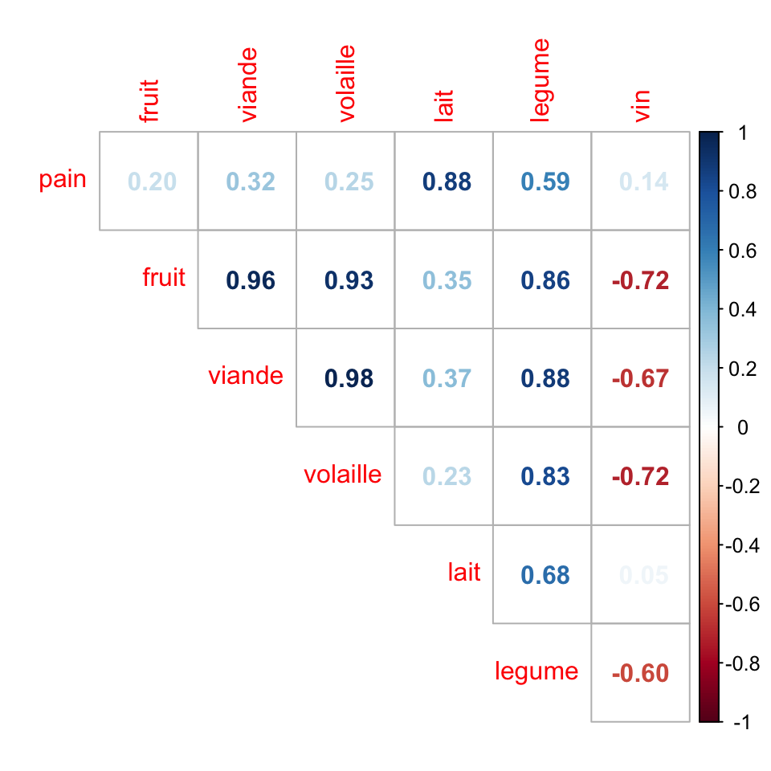

# Présentation de l’ACP

## Étude des inerties

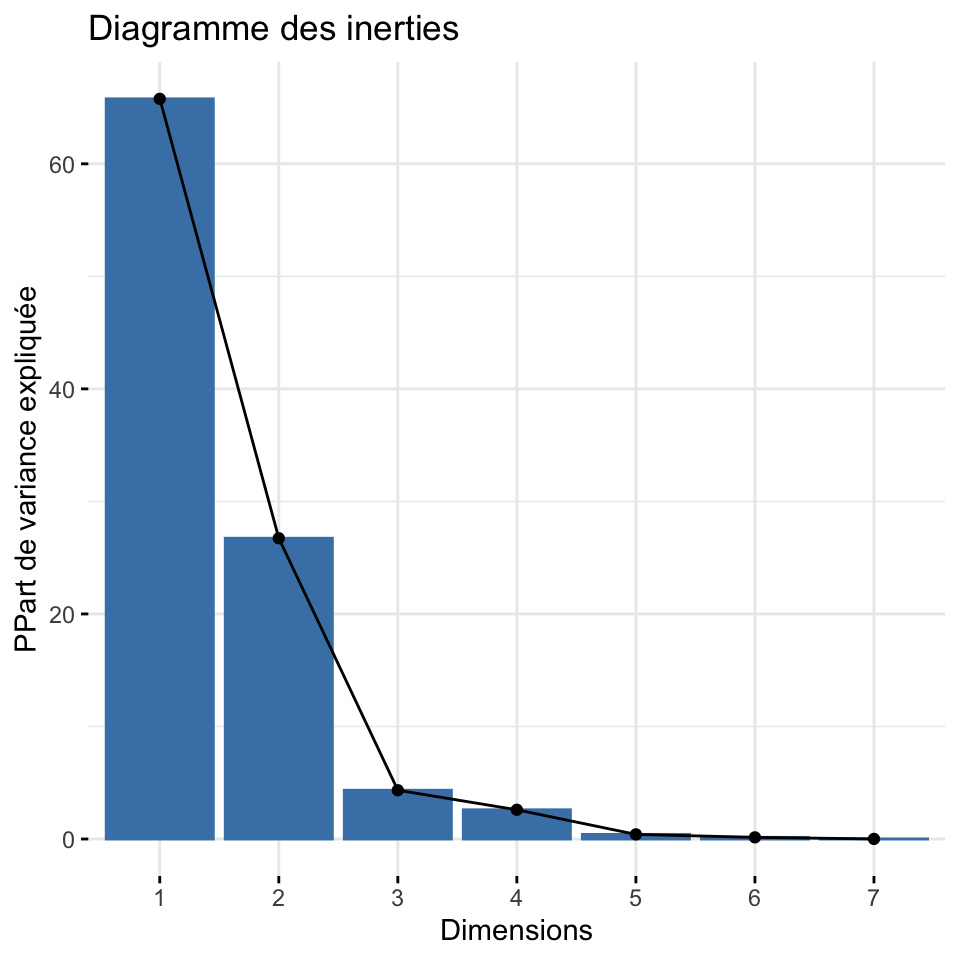

| F1 | F2 | F3 | F4 | F5 | F6 | F7 |
| --- | --- | --- | --- | --- | --- | --- |
| 65.77 | 92.5 | 96.83 | 99.43 | 99.85 | 99.99 | 100 |

On conserve les deux premiers axes qui cumulent 92.5 $\%$ d’inertie.

## Étude des variables

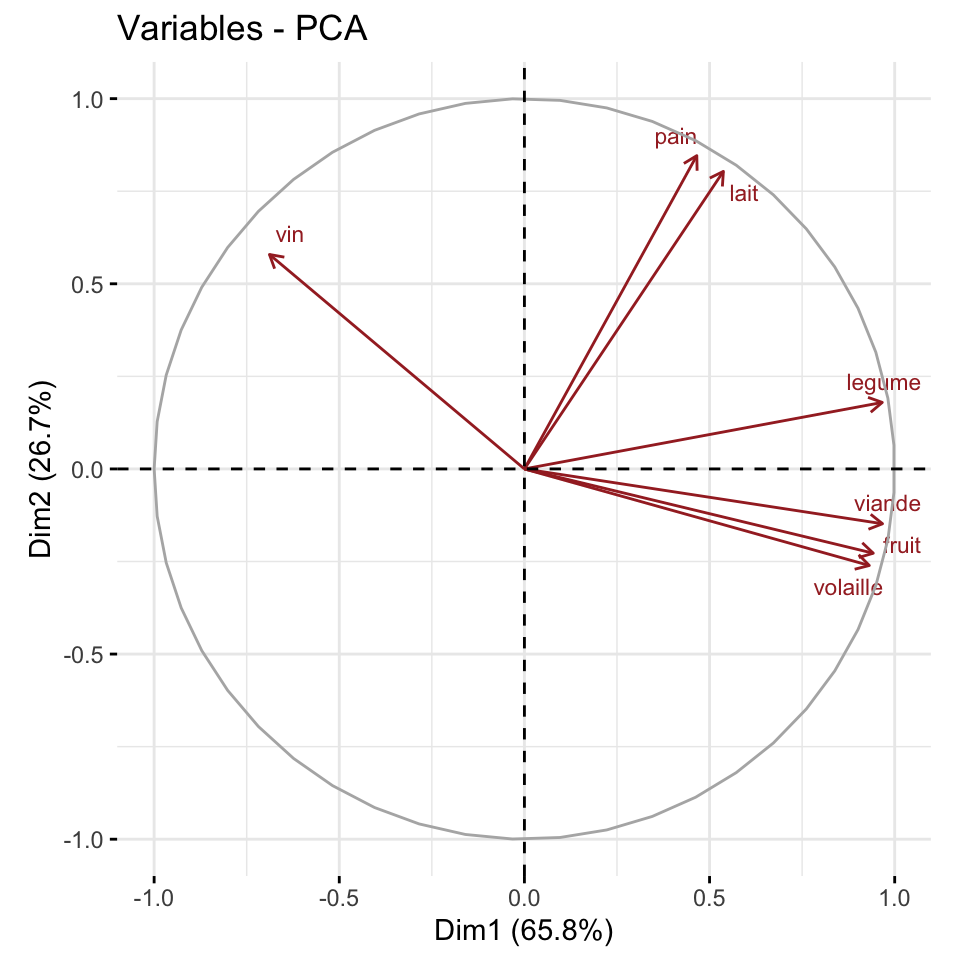

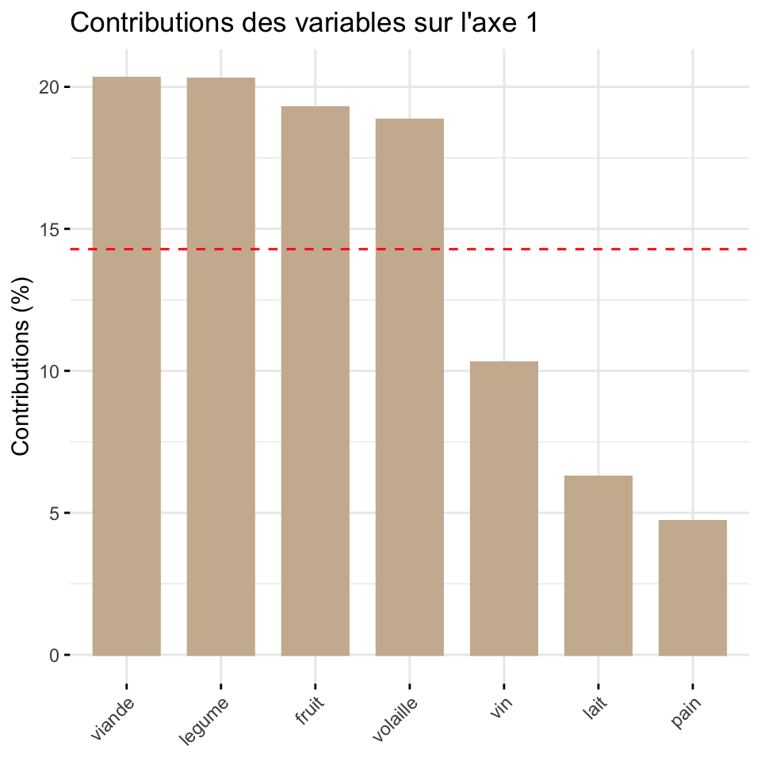

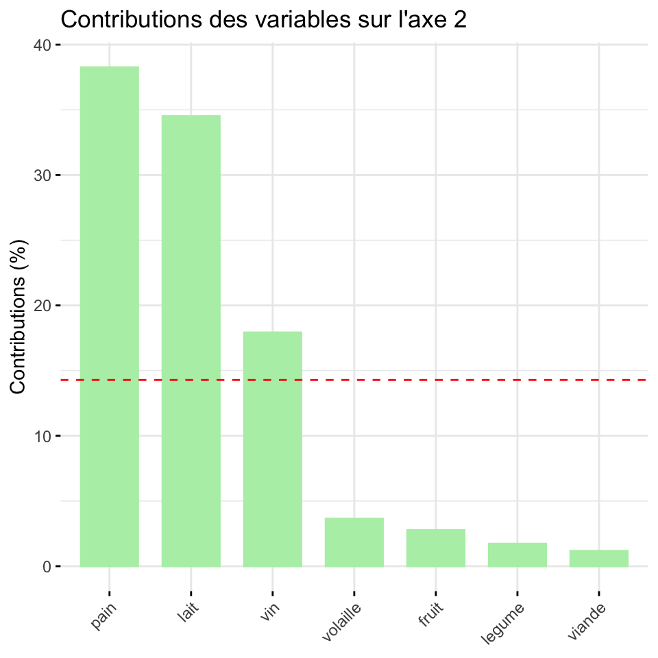

On vérifie bien l’observation faite dans le tableau des corrélations.

- L’axe $F_1$ synthétise les variables **viande**, **légume**, **fruit** et **volaille** et ces variables contribuent à 78.7 $\%$.
- L’axe $F_2$ synthétise les variables pain et lait en contribuant 72.8$\%$.

## Étude des individus

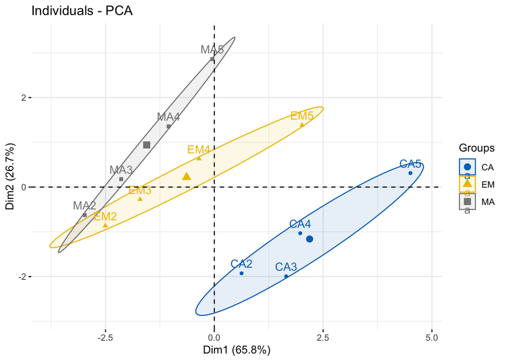

On observe clairement 3 “droites”, une pour chaque CSP, à peu près parallèles à la première bissectrice. On observe que le nombre d’enfants à charge est croissant en allant en “haut à droite”. La droite des **travailleurs manuels ‘MA’** est la plus à gauche, au milieu, celle des **employés ‘EM’** et celle des **cadres ‘CA’** à droite.

On peut superposer les deux graphiques

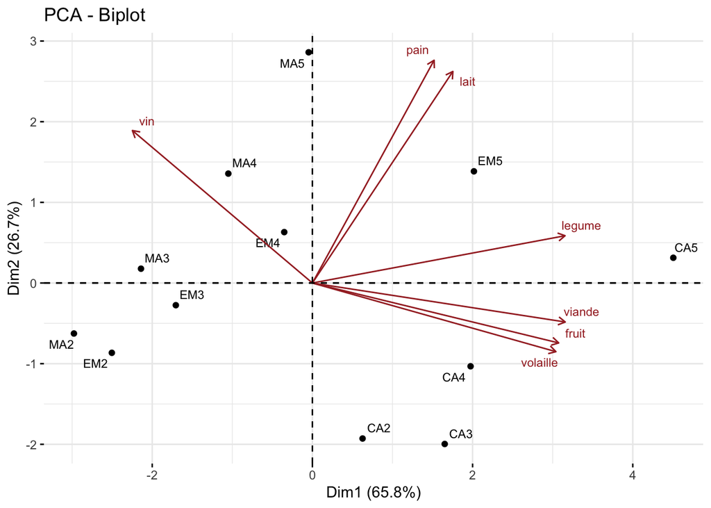

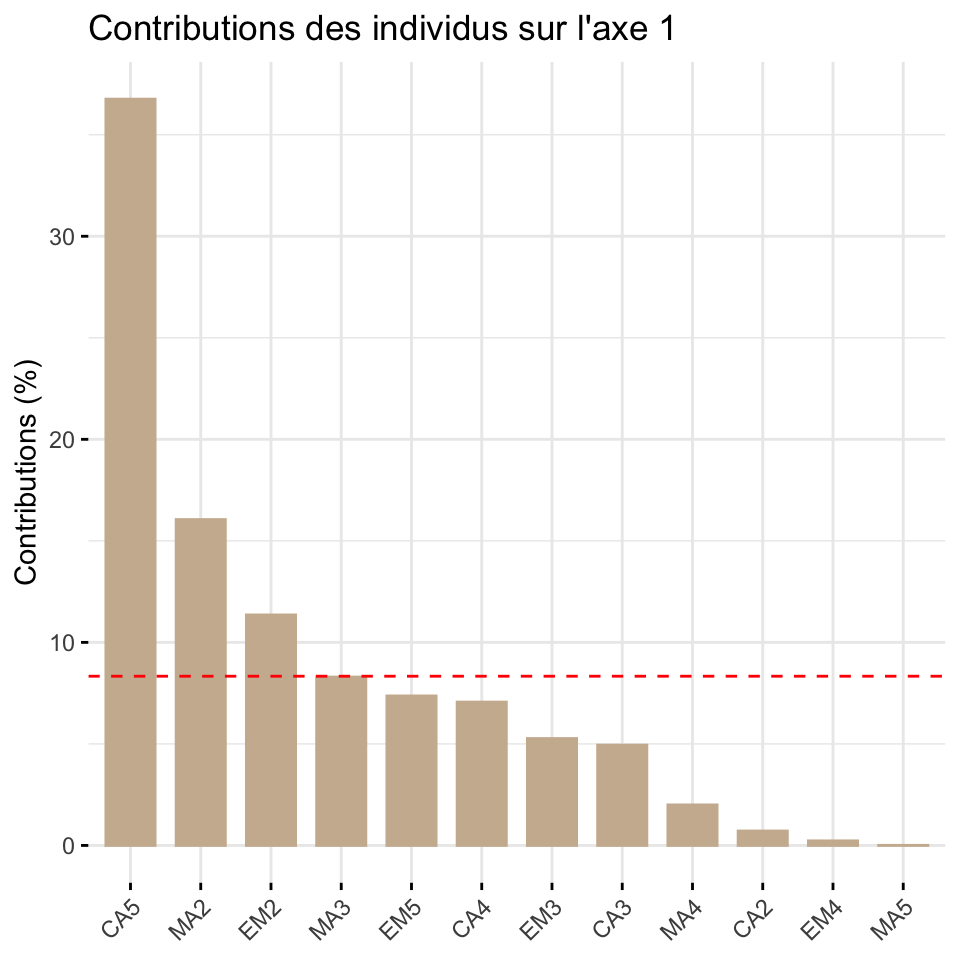

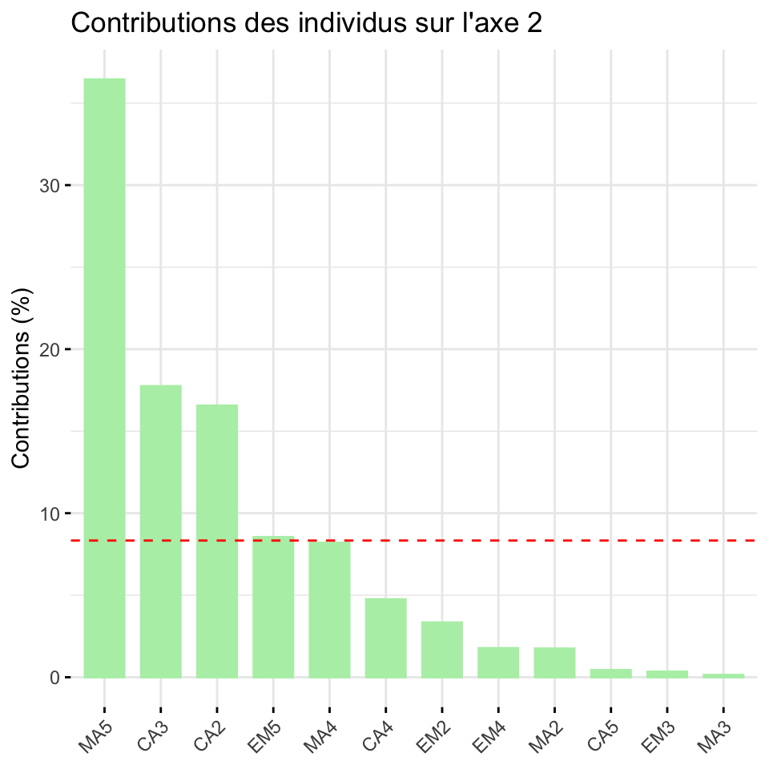

L’étude des contributions vient confirmer ce que nous voyons sur le graphique car l’ACP est normée. Mais cela n’aide pas à l’interprétation car on voit clairement que les regroupements se font “diagonalement”.

Il faut distinguer deux choses :

- plus une famille a d’enfants, plus les quantités sont importantes pour toutes les variables selon les CSP. On s’aperçoit que les 3 droites ont à peu près la même direction que les variables **pain** et **lait**. Ce qui signifie que quelque soit la catégorie socio-professionnelle, les familles consomment ces denrées et la quantité varie selon la taille de la famille.
- Les cadres consacrent un budget plus important à la **viande**, **légume**, **fruit** et **volaille** que les employés : ce sont des denrées plus onéreuses. La CSP cadre a une capacité financière qui permet d’y accéder plus facilement que les deux autres. Cela se traduit graphiquement par ce décallage suivant l’axe $F_1$.